# Insurance_Claims_Analysis

Sai Varadharajan

8/13/2023

### Loading in Libraries

```r
library(tidyverse)
```

```r
library(dplyr)
library(ggplot2)
library(patchwork)
```

### Reading in Dataset

```r
df_insurance <- read_csv("Insurance_factor_identification.csv")
str(df_insurance)
```

```
## spc_tbl_ [2,182 x 7] (S3: spec_tbl_df/tbl_df/tbl/data.frame)
##  $ Kilometres: num [1:2182] 1 1 1 1 1 1 1 1 1 1 ...
##  $ Zone      : num [1:2182] 1 1 1 1 1 1 1 1 1 1 ...
##  $ Bonus     : num [1:2182] 1 1 1 1 1 1 1 1 1 2 ...
##  $ Make      : num [1:2182] 1 2 3 4 5 6 7 8 9 1 ...
##  $ Insured   : num [1:2182] 455.1 69.2 72.9 1292.4 191 ...
##  $ Claims    : num [1:2182] 108 19 13 124 40 ...
##  $ Payment   : num [1:2182] 392491 46221 15694 422201 119373 ...
##  - attr(*, "spec")=
##   .. cols(
##   ..   Kilometres = col_double(),
##   ..   Zone = col_double(),
##   ..   Bonus = col_double(),
##   ..   Make = col_double(),
##   ..   Insured = col_double(),
##   ..   Claims = col_double(),
##   ..   Payment = col_double()
##   .. )
##  - attr(*, "problems")=<externalptr>
```

## Analysis Task 1: The committee is interested to know each field of the data collected through descriptive analysis to gain basic insights into the data set and to prepare for further analysis.

```r
summary(df_insurance)
```

```
##    Kilometres         Zone          Bonus            Make
##  Min.   :1.000   Min.   :1.00   Min.   :1.000   Min.   :1.000
##  1st Qu.:2.000   1st Qu.:2.00   1st Qu.:2.000   1st Qu.:3.000
##  Median :3.000   Median :4.00   Median :4.000   Median :5.000
##  Mean   :2.986   Mean   :3.97   Mean   :4.015   Mean   :4.992
##  3rd Qu.:4.000   3rd Qu.:6.00   3rd Qu.:6.000   3rd Qu.:7.000
##  Max.   :5.000   Max.   :7.00   Max.   :7.000   Max.   :9.000
##     Insured              Claims           Payment
##  Min.   :     0.01   Min.   :   0.00   Min.   :       0
##  1st Qu.:    21.61   1st Qu.:   1.00   1st Qu.:    2989
##  Median :    81.53   Median :   5.00   Median :   27404
##  Mean   :  1092.20   Mean   :  51.87   Mean   :  257008
##  3rd Qu.:   389.78   3rd Qu.:  21.00   3rd Qu.:  111954
##  Max.   :127687.27   Max.   :3338.00   Max.   :18245026
```

Checking for Missing Values:

```r
sum(is.na(df_insurance)) # no missing values
```

```
## [1] 0
```

Checking ranges of each column to make sure values make sense:

Kilometers- Values should be between 1 and 5, Zone: There are supposed to be 7 zones, from 1-7 Bonus: Min value should be 1, since it is calculated by number of years since last claim + 1 Make: There are 9 categories for Make Insured- Number of insured policy years. Seems to be positively Skewed. Claims- Seems to be positively Skewed. Payments: Seems to be positively Skewed.

```r
df_processed_insurance <- df_insurance %>%
  mutate(
    Zone=as.factor(Zone),
    Make=as.factor(Make),
    Bonus=as.factor(Bonus),
    Kilometres=as.factor(Kilometres)
  )
str(df_processed_insurance)
```

```
## tibble [2,182 x 7] (S3: tbl_df/tbl/data.frame)
##  $ Kilometres: Factor w/ 5 levels "1","2","3","4",..: 1 1 1 1 1 1 1 1 1 1 ...
##  $ Zone      : Factor w/ 7 levels "1","2","3","4",..: 1 1 1 1 1 1 1 1 1 1 ...
##  $ Bonus     : Factor w/ 7 levels "1","2","3","4",..: 1 1 1 1 1 1 1 1 1 2 ...
##  $ Make      : Factor w/ 9 levels "1","2","3","4",..: 1 2 3 4 5 6 7 8 9 1 ...
##  $ Insured   : num [1:2182] 455.1 69.2 72.9 1292.4 191 ...
##  $ Claims    : num [1:2182] 108 19 13 124 40 ...
##  $ Payment   : num [1:2182] 392491 46221 15694 422201 119373 ...
```

Handling Outliers: Insured, Claims, Payments

Viewing Distributions:

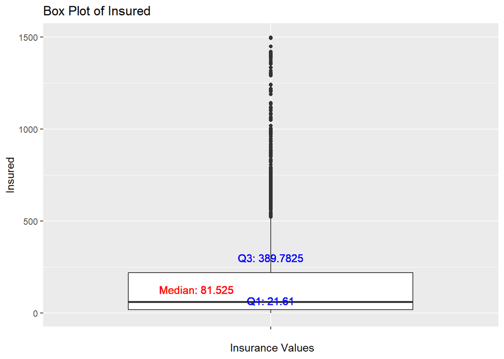

```r
q1 <- quantile(df_processed_insurance$Insured, 0.25)
median <- median(df_processed_insurance$Insured)
q3 <- quantile(df_processed_insurance$Insured, 0.75)


ggplot(df_processed_insurance) +
  geom_boxplot(aes(x = "", y = Insured)) +
  labs(title = "Box Plot of Insured",x=" Insurance Values") +
  scale_y_continuous(limits = c(0, 1500))+
geom_text(aes(x = 1, y = q1, label = paste("Q1:", q1)),
            vjust = -0.5, hjust = 0.5, color = "blue") +
  geom_text(aes(x = 1, y = median, label = paste("Median:", median)),
            vjust = -0.5, hjust = 1.5, color = "red") +
  geom_text(aes(x = 1, y = q3, label = paste("Q3:", q3)),
            vjust = 2.5, hjust = 0.5, color = "blue")
```

Viewing insured by Make

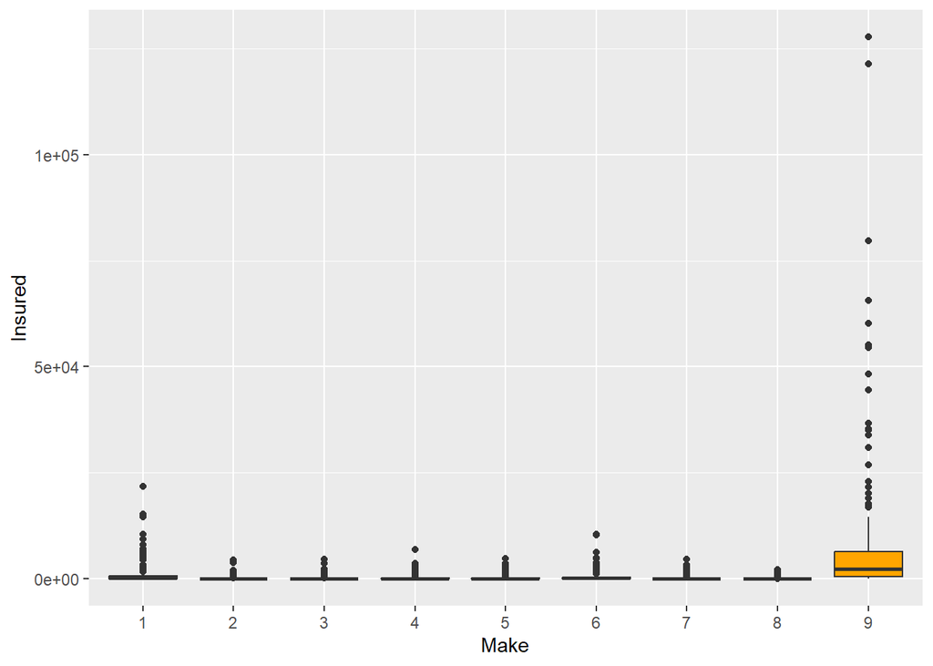

```r
make_vs_insured <- ggplot(df_processed_insurance)+
  geom_boxplot(aes(x=Make,y=Insured),fill="orange")

make_vs_insured
```

It seems like the extreme values are coming mostly from the ninth make, which is the Others Category

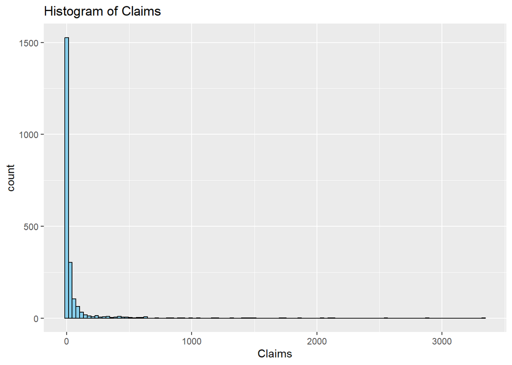

```r
ggplot(df_processed_insurance) +
  geom_histogram(aes(x = Claims), binwidth = 30, fill = "skyblue", color = "black") +
  labs(title = "Histogram of Claims")
```

There seems to numerous claim counts past the interquartile range of 1-21, indicating significant variability and dispersion. These outliers seem valid and could possibly lead to insights, so I will keep them as it is without applying log transformations.

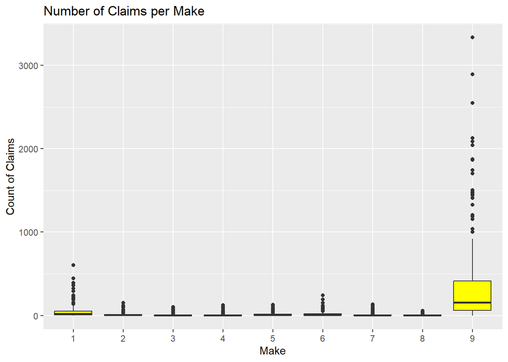

```r
make_vs_claims <- ggplot(df_processed_insurance) +
  geom_boxplot(aes(x = Make, y=Claims),fill="yellow") +
  labs(title = "Number of Claims per Make", y="Count of Claims")
make_vs_claims
```

It seems like the larger values for claims come from the “Others” section, aka Make 9. For the most part, claims are well below 500 for the other Makes.

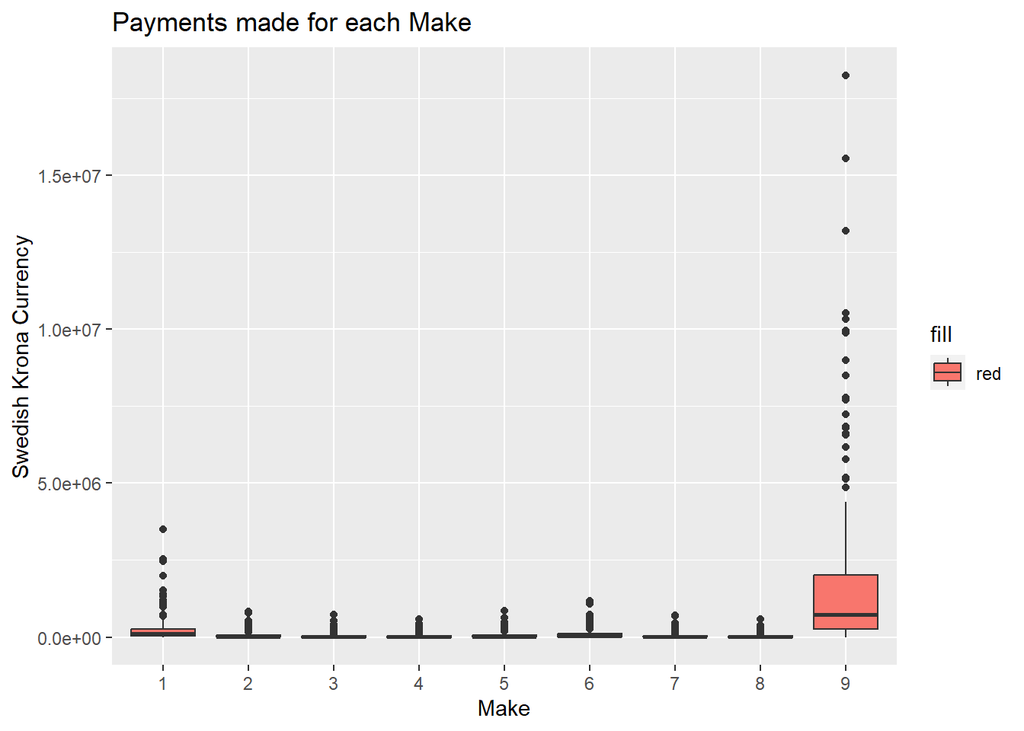

```r
make_vs_payment <- ggplot(df_processed_insurance) +
  geom_boxplot(aes(x = Make, y=Payment,fill="red")) +
  labs(title = "Payments made for each Make", y="Swedish Krona Currency")
make_vs_payment
```

It makes sense why Make 9 has such a wide dispersion, since it represents the “Other” category. The dispersion and variability is fairly low for categories 2-8.

As we can see, most of the variability and extreme values comes from the “Others” Make category, Category 9

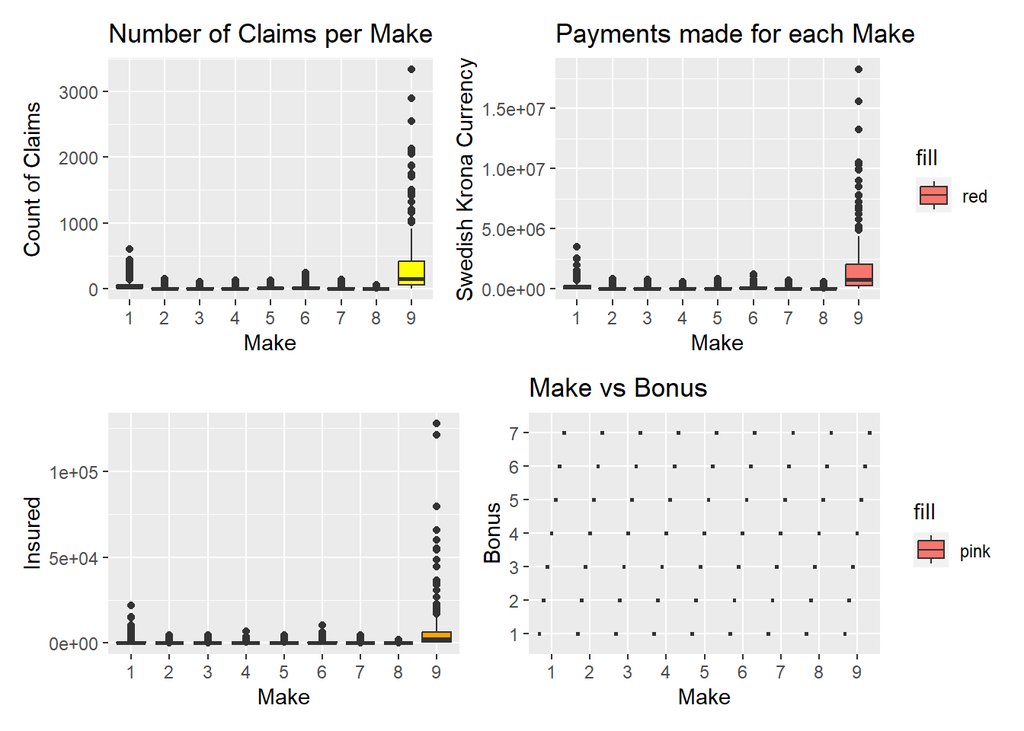

```r
# plotting Make against bonus as well

make_vs_bonus <- ggplot(df_processed_insurance) +
  geom_boxplot(aes(x = Make, y=Bonus,fill="pink")) +
  labs(title = "Make vs Bonus", y="Bonus")

(make_vs_claims + make_vs_payment) /(make_vs_insured + make_vs_bonus)
```

It seems like Category 9 does not have any strange outliers when it comes to the Bonus section, strangely.

### Distributions of Distance Traveled, Origin, and Make

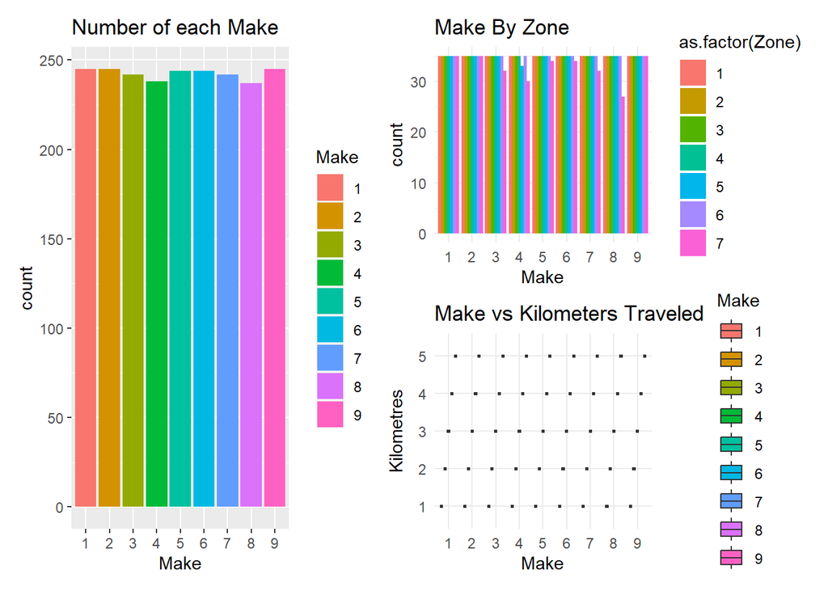

```r
bar_make <- ggplot(df_processed_insurance)+
  geom_bar(aes(x=Make,fill=Make)) +
  labs(title="Number of each Make")

 make_by_zone <- ggplot(df_processed_insurance, aes(x = Make, fill = as.factor(Zone))) +
  geom_bar(position = "dodge") +
  labs(title = "Make By Zone") +
  theme_minimal()

make_vs_km <- ggplot(df_processed_insurance, aes(x = Make, y = Kilometres,fill=Make)) +
  geom_boxplot() +
  labs(title = "Make vs Kilometers Traveled") +
  theme_minimal()

bar_make +  make_by_zone /make_vs_km
```

The dataset seems to have a roughly equal number of each Make. This is interesting since the Ninth make, Others, is responsible for a disproportionally large amount of variance and outliers. Make 9 seems to have the same dispersion in Kilometers as well as zone as compared to the other Makes, which is strange since it has such high variability and outliers in terms of Claims, Payments, and Insured.

Using hypotheseis testing to check if the observed differences between Makes 1-8 and 9 are due to chance or are statistically significant:

Insured Variable:

Null Hypothesis, H0- There is so significant difference between Insured status between Make 9 and the other makes Alternative Hypothesis H1- There is a signficant difference between Insured status between the two groups. Significance level: 0.05

```r
make9_data <- df_processed_insurance %>%
filter(Make == 9)

other_makes_data <- df_processed_insurance %>%
  filter(Make != 9)

# Perform independent samples t-test
ttest_result <- t.test(make9_data$Insured, other_makes_data$Insured)

# Print the t-test result
print(ttest_result)
```

```
##
##  Welch Two Sample t-test
##
## data:  make9_data$Insured and other_makes_data$Insured
## t = 6.7922, df = 244.31, p-value = 8.351e-11
## alternative hypothesis: true difference in means is not equal to 0
## 95 percent confidence interval:
##  4746.680 8624.199
## sample estimates:
## mean of x mean of y
## 7026.9784  341.5387
```

```r
str(colnames(df_processed_insurance))
```

```
##  chr [1:7] "Kilometres" "Zone" "Bonus" "Make" "Insured" "Claims" "Payment"
```

```r
for (col in colnames(df_processed_insurance)) {
  print(col)
}
```

```
## [1] "Kilometres"
## [1] "Zone"
## [1] "Bonus"
## [1] "Make"
## [1] "Insured"
## [1] "Claims"
## [1] "Payment"
```

```r
make9_data <- df_insurance %>% # using original dataset because every column in original is numeric
filter(Make == 9)

other_makes_data <- df_insurance %>%
  filter(Make != 9)

# Perform independent samples t-test
for (col in colnames(df_insurance)) {
  cat("Checking column:", col, "\n")
  ttest_result <- t.test(make9_data[[col]], other_makes_data[[col]])
  # Print the t-test result
  print(ttest_result)
}
```

```
## Checking column: Kilometres
##
##  Welch Two Sample t-test
##
## data:  make9_data[[col]] and other_makes_data[[col]]
## t = 0.16665, df = 308.32, p-value = 0.8678
## alternative hypothesis: true difference in means is not equal to 0
## 95 percent confidence interval:
##  -0.1729654  0.2049737
## sample estimates:
## mean of x mean of y
##  3.000000  2.983996
##
## Checking column: Zone
##
##  Welch Two Sample t-test
##
## data:  make9_data[[col]] and other_makes_data[[col]]
## t = 0.24717, df = 307.88, p-value = 0.8049
## alternative hypothesis: true difference in means is not equal to 0
## 95 percent confidence interval:
##  -0.2335908  0.3007049
## sample estimates:
## mean of x mean of y
##  4.000000  3.966443
##
## Checking column: Bonus
##
##  Welch Two Sample t-test
##
## data:  make9_data[[col]] and other_makes_data[[col]]
## t = -0.12539, df = 308.77, p-value = 0.9003
## alternative hypothesis: true difference in means is not equal to 0
## 95 percent confidence interval:
##  -0.2843778  0.2503045
## sample estimates:
## mean of x mean of y
##  4.000000  4.017037
##
## Checking column: Make
```

[output cut: 35 more lines]

```
## mean of x mean of y
## 342.24082  15.13784
##
## Checking column: Payment
##
##  Welch Two Sample t-test
##
## data:  make9_data[[col]] and other_makes_data[[col]]
## t = 9.6888, df = 244.36, p-value < 2.2e-16
## alternative hypothesis: true difference in means is not equal to 0
## 95 percent confidence interval:
##  1273828 1923930
## sample estimates:
##  mean of x  mean of y
## 1676360.67   77481.84
```

It seems like Make 9 is statistically significant in terms of Number of Claims, Payment, and Insured but not in terms of Kilometers traveled and Bonuses.

This could indicate that this category has specific characteristics that lead to higher claims, payments, and insured amounts. This might be due to certain features of the vehicles in this category, driving patterns, or other factors unique to “Make 9.”

## Analysis Task 2: The total value of payment by an insurance company is an important factor to be monitored. So the committee has decided to find whether this payment is related to the number of claims and the number of insured policy years. They also want to visualize the results for better understanding.

My approach:

Using regression lines and plotting Payment vs Insured and Claims and checking the regression line. I was also considering doing it separately for models 1-8 and model 9.

Payment vs Insured

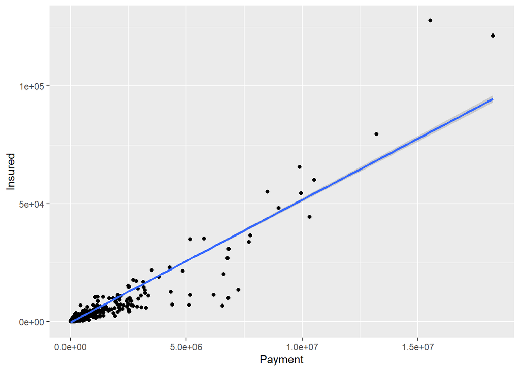

```r
ggplot(df_processed_insurance,aes(x=Payment,y=Insured)) +
  geom_point() +
  geom_smooth(method="lm")
```

R squared value:

```r
lm_model <- lm(Insured~ Payment, data = df_processed_insurance)
rsquared <- summary(lm_model)$r.squared
rsquared
```

```
## [1] 0.8708939
```

Payment vs Claims

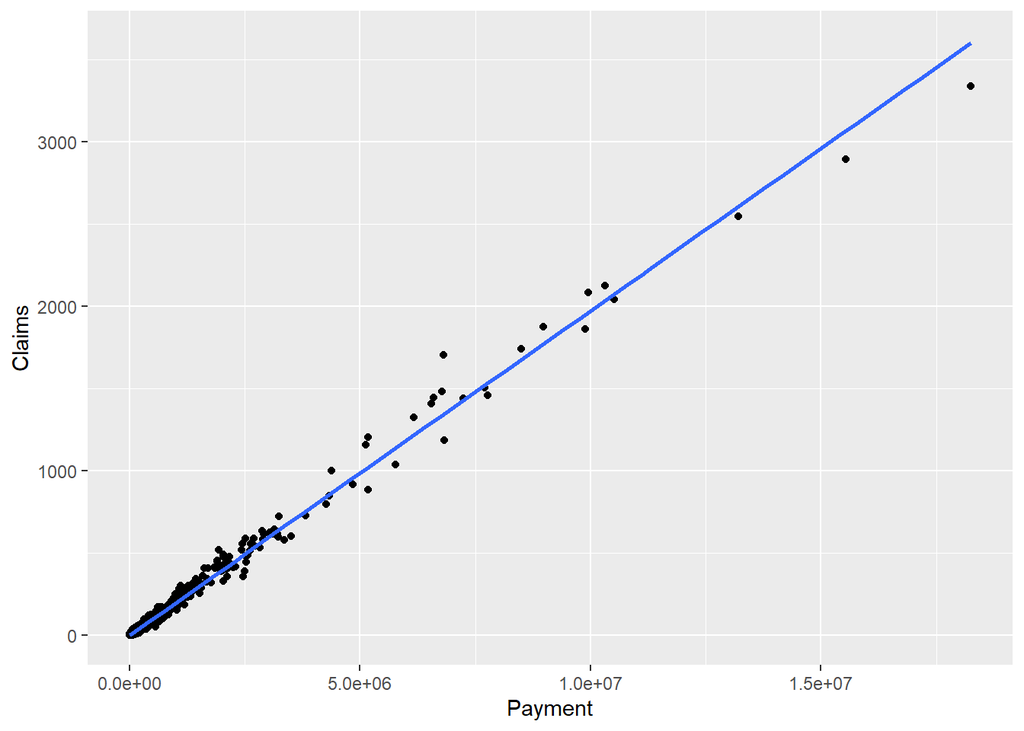

```r
ggplot(df_processed_insurance,aes(x=Payment,y=Claims)) +
  geom_point() +
  geom_smooth(method="lm")
```

R squared value:

```r
lm_model <- lm(Claims ~ Payment, df_processed_insurance)
summary(lm_model)$r.squared
```

```
## [1] 0.9908217
```

### Analysis Task 3

the committee wants to figure out the reasons for insurance payment increase and decrease. So they have decided to find whether distance, location, bonus, make, and insured amount or claims are affecting the payment or all or some of these are affecting it.

Approach: I’ll use multiple linear regression and check each independent variable for statistical significance, i.e. if their p-value is less than 0.05.

```r
multiplelm <- lm(Payment ~ .,df_insurance)
summary(multiplelm)
```

```
##
## Call:
## lm(formula = Payment ~ ., data = df_insurance)
##
## Residuals:
##     Min      1Q  Median      3Q     Max
## -806775  -16943   -6321   11528  847015
##
## Coefficients:
##               Estimate Std. Error t value Pr(>|t|)
## (Intercept) -2.173e+04  6.338e+03  -3.429 0.000617 ***
## Kilometres   4.769e+03  1.086e+03   4.392 1.18e-05 ***
## Zone         2.323e+03  7.735e+02   3.003 0.002703 **
## Bonus        1.183e+03  7.737e+02   1.529 0.126462
## Make        -7.543e+02  6.107e+02  -1.235 0.216917
## Insured      2.788e+01  6.652e-01  41.913  < 2e-16 ***
## Claims       4.316e+03  1.895e+01 227.793  < 2e-16 ***
## ---
## Signif. codes:  0 '***' 0.001 '**' 0.01 '*' 0.05 '.' 0.1 ' ' 1
##
## Residual standard error: 70830 on 2175 degrees of freedom
## Multiple R-squared:  0.9952, Adjusted R-squared:  0.9952
## F-statistic: 7.462e+04 on 6 and 2175 DF,  p-value: < 2.2e-16
```

We can see that Kilometers, Zome, Insured and Claims are statistically significant while Bonus and Make are not, implying that the former affect Payment while the latter do not.

### Analysis Task 4:

The insurance company is planning to establish a new branch office, so they are interested to find at what location, kilometre, and bonus level their insured amount, claims, and payment gets increased.

Approach : Group by location, km, bonus level and summarize mean amount, claims, and payment

```r
agg_data <- df_processed_insurance %>%
  group_by(Kilometres, Zone, Bonus) %>%
  summarise(
    mean_insured= mean(Insured),
    mean_claims=mean(Claims),
    mean_payment=mean(Payment)

  )
agg_data
```

```
## # A tibble: 245 x 6
## # Groups:   Kilometres, Zone [35]
##    Kilometres Zone  Bonus mean_insured mean_claims mean_payment
##    <fct>      <fct> <fct>        <dbl>       <dbl>        <dbl>
##  1 1          1     1            1411.       234.       900812.
##  2 1          1     2             907.        87.7      392782.
##  3 1          1     3             710.        54.6      237739.
##  4 1          1     4             601.        42        192112.
##  5 1          1     5             684.        41.8      164829.
##  6 1          1     6            1330.        73.6      283281
##  7 1          1     7            7007.       263.      1262024.
##  8 1          2     1            1612.       184.       847469.
##  9 1          2     2            1089.        80.9      340972.
## 10 1          2     3             843.        44.2      195208.
## # i 235 more rows
```

```r
summary(agg_data)
```

```
##  Kilometres Zone   Bonus   mean_insured        mean_claims
##  1:49       1:35   1:35   Min.   :    4.102   Min.   :  0.1429
##  2:49       2:35   2:35   1st Qu.:   90.372   1st Qu.:  9.1111
##  3:49       3:35   3:35   Median :  354.789   Median : 23.2222
##  4:49       4:35   4:35   Mean   : 1080.938   Mean   : 51.3334
##  5:49       5:35   5:35   3rd Qu.:  953.541   3rd Qu.: 61.3333
##             6:35   6:35   Max.   :19543.612   Max.   :530.3333
##             7:35   7:35
##   mean_payment
##  Min.   :    187.7
##  1st Qu.:  42803.8
##  Median : 115768.9
##  Mean   : 254356.2
##  3rd Qu.: 301360.1
##  Max.   :2917259.9
##
```

```r
ordered_agg_data <- agg_data[order(-agg_data$mean_insured, -agg_data$mean_claims, -agg_data$mean_payment), ]
ordered_agg_data
```

```
## # A tibble: 245 x 6
## # Groups:   Kilometres, Zone [35]
##    Kilometres Zone  Bonus mean_insured mean_claims mean_payment
##    <fct>      <fct> <fct>        <dbl>       <dbl>        <dbl>
##  1 2          4     7           19544.        530.     2917260.
##  2 1          4     7           19143.        434.     2357821.
##  3 3          4     7           12956.        404.     2169422.
##  4 1          3     7            9720.        271.     1407028.
##  5 2          3     7            9577.        314.     1581017.
##  6 2          2     7            8518.        323.     1637884.
##  7 1          2     7            8057.        254.     1225560.
##  8 1          1     7            7007.        263.     1262024.
##  9 2          1     7            6919.        327.     1612848.
## 10 3          3     7            5912.        228.     1190439.
## # i 235 more rows
```

Based on this table, I’d recommend Zone 4, which has the top 3 highest mean Insured , claims amd payment values.

### Analysis Task 5:

The committee wants to understand what affects their claim rates so as to decide the right premiums for a certain set of situations. Hence, they need to find whether the insured amount, zone, kilometre, bonus, or make affects the claim rates and to what extent.

Approach: I will check the p values for statistical significance and check the coefficients for magnitude of effect.

```r
lm_claimrates <- lm(Claims ~Insured + Zone + Kilometres + Bonus, df_insurance)
summary(lm_claimrates)
```

```
##
## Call:
## lm(formula = Claims ~ Insured + Zone + Kilometres + Bonus, data = df_insurance)
##
## Residuals:
##      Min       1Q   Median       3Q      Max
## -1261.85   -22.73   -10.41     3.46  1323.46
##
## Coefficients:
##               Estimate Std. Error t value Pr(>|t|)
## (Intercept) 70.3776515  6.4506713  10.910  < 2e-16 ***
## Insured      0.0324676  0.0003171 102.397  < 2e-16 ***
## Zone        -6.2337598  0.8842625  -7.050 2.40e-12 ***
## Kilometres  -3.7230168  1.2529737  -2.971    0.003 **
## Bonus       -4.5097923  0.8899970  -5.067 4.38e-07 ***
## ---
## Signif. codes:  0 '***' 0.001 '**' 0.01 '*' 0.05 '.' 0.1 ' ' 1
##
## Residual standard error: 81.95 on 2177 degrees of freedom
## Multiple R-squared:  0.8352, Adjusted R-squared:  0.8349
## F-statistic:  2759 on 4 and 2177 DF,  p-value: < 2.2e-16
```

We can see that the Insured amount, zone, kilometre, bonus all are statistically significant, meaning that they affect the Claims rate. Zone seems to have the strongest magnitude of effect at -6, followed by Bonus at -4 and Kilometers at -3, and then by Insured at 0.03.